# HW6 Michal Grotkowski

## PVI comparision between different models

Below we can see the performance and PVI results for 4 models trained on adult income dataset: an XGBoost classifier, an XGBoost classifier with a smaller learning rate, a Logistic Regression model and a Random Forest classifier.

```python
print("XGBoost accuracy: %s \nXGBoost different eta accuracy %s \nLogistic Regression accuracy: %s \nRandom Forest Accuracy: %s" % (accuracy(xgb_model),accuracy(xgb_model_different_eta), accuracy(linear_model), accuracy(rf_model)))
```

```
XGBoost accuracy: 0.8754222540689938
XGBoost different eta accuracy 0.7606715119254785
Logistic Regression accuracy: 0.8537209540382844
Random Forest Accuracy: 0.8561777049851571
```

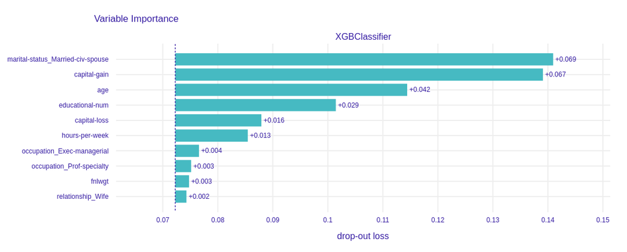

```python
xgb_pv.plot(show=False).update_layout(autosize=False, width=600, height=450)
```

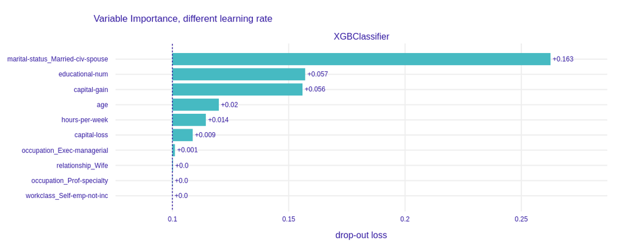

```python
xgb2_pv.plot(show=False, title = 'Variable Importance, different learning rate').update_layout(autosize=False, width=600, height=450)
```

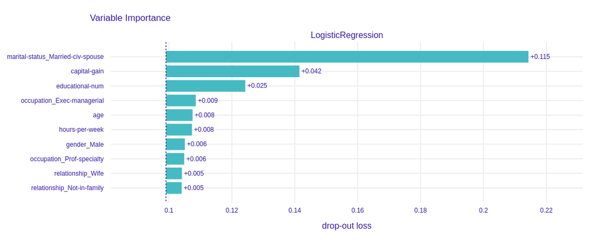

```python
logistic_pv.plot(show=False).update_layout(autosize=False, width=600, height=450)
```

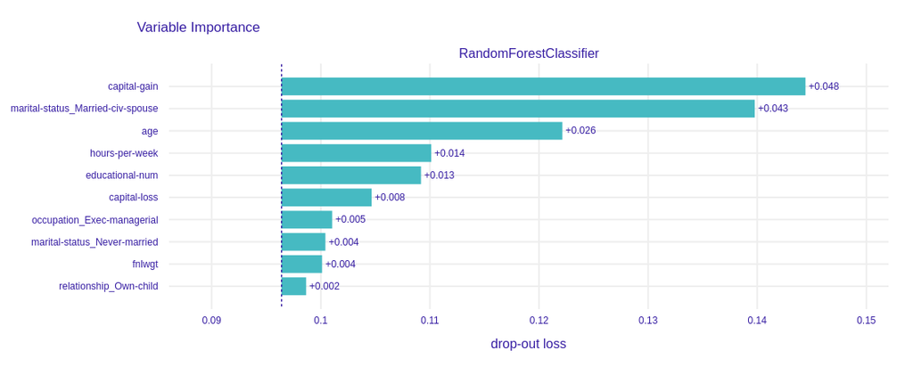

```python
rf_pv.plot(show=False).update_layout(autosize=False, width=600, height=450)
```

The results above showcase two classes of models: tree-based and linear model based. Tree-based models can take into account relationships between variables while the logistic regression model cannot. We can see that both tree-based models: XGBoost and Random Forest show the same three variables with highest PVI values. Logistic Regression overlaps in 2/3 of these variables, giving a higher importance to educational-num than age, compared to tree-based model. This may be a result of not capturing a relationship between one of those top variables or a smaller coefficient assigned to age variable resulting in a smaller loss difference.  
There is another case with XGBoost with a smaller learning rate that performs the worst out of the 4 models. It also does not acknowledge the age in the top 3 features. The smaller learning rate and thus slower convergence may have not allowed the model to create a desired split to capture the variable's importance.

# XGBoost PVI comparision with other importance estimation methods

The top 5 most important features mostly overlap between PVI and averaged Shapley values and gain-based importance estimations. What is interesting the gain results do not include the age variable, which is featured in a high spot in other importance metrics. This may be due to the particular nature of gain computation, where a split is made in order to estimate the accuracy gain. This approach may value binary features more highly as there are fewer splits to make, compared to age variable which has more values. This problem is not seen in Shapley estimates as this method is based on sampling.

```python
importances = xgb_model.feature_importances_
print("XGBoost feature importance")
for col, imp in zip(X_test.columns[np.flip(np.argpartition(importances, -5)[-5:])], np.sort(importances)[::-1]):
    print("Feature: %s, importance: %s" % (col, imp))
```

```
XGBoost feature importance
Feature: marital-status_Married-civ-spouse, importance: 0.41117296
Feature: educational-num, importance: 0.053924184
Feature: capital-gain, importance: 0.05141079
Feature: occupation_Other-service, importance: 0.0302483
Feature: relationship_Own-child, importance: 0.029988348
```

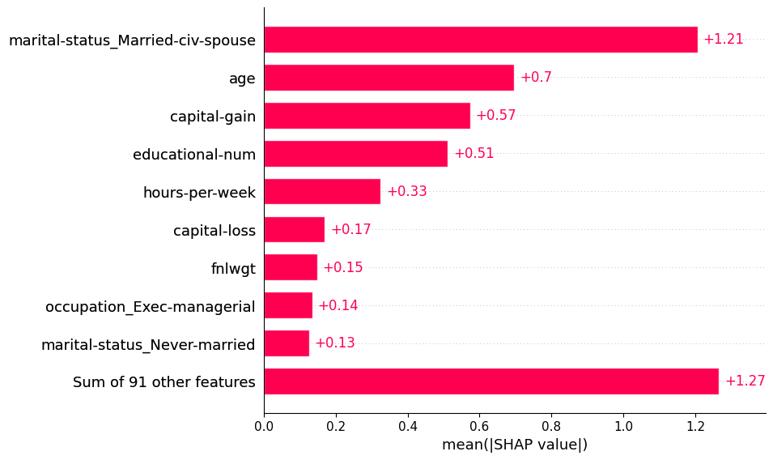

```python
shap.plots.bar(shap_vals)
```

## Appenidx

```python
from google.colab import files
files.upload()
!unzip archive.zip
```

Upload widget is only available when the cell has been executed in the current browser session. Please rerun this cell to enable.

```
Saving archive.zip to archive (1).zip
Archive:  archive.zip
replace adult.csv? [y]es, [n]o, [A]ll, [N]one, [r]ename: n
```

```python
import pandas as pd
df = pd.read_csv("adult.csv")
df["income"] = pd.get_dummies(df["income"], drop_first = True)
cols=df.select_dtypes(exclude=['int', 'uint8']).columns.to_list()
df[cols] = df[cols].astype("category")

X = df.iloc[:, :-1]
target = df["income"]
X.head()
```

|  | age | workclass | fnlwgt | education | educational-num | marital-status | occupation | relationship | race | gender | capital-gain | capital-loss | hours-per-week | native-country |
| --- | --- | --- | --- | --- | --- | --- | --- | --- | --- | --- | --- | --- | --- | --- |
| 0 | 25 | Private | 226802 | 11th | 7 | Never-married | Machine-op-inspct | Own-child | Black | Male | 0 | 0 | 40 | United-States |
| 1 | 38 | Private | 89814 | HS-grad | 9 | Married-civ-spouse | Farming-fishing | Husband | White | Male | 0 | 0 | 50 | United-States |
| 2 | 28 | Local-gov | 336951 | Assoc-acdm | 12 | Married-civ-spouse | Protective-serv | Husband | White | Male | 0 | 0 | 40 | United-States |
| 3 | 44 | Private | 160323 | Some-college | 10 | Married-civ-spouse | Machine-op-inspct | Husband | Black | Male | 7688 | 0 | 40 | United-States |
| 4 | 18 | ? | 103497 | Some-college | 10 | Never-married | ? | Own-child | White | Female | 0 | 0 | 30 | United-States |

```python
from sklearn.model_selection import train_test_split
X_train, X_test, target_train, target_test = train_test_split(pd.get_dummies(X, drop_first = True), target, random_state = 42, train_size = 0.8, stratify = target)
```

```python
import xgboost as xgb
from sklearn.metrics import accuracy_score
from sklearn.linear_model import LogisticRegression
from sklearn.pipeline import make_pipeline
from sklearn.preprocessing import StandardScaler
from sklearn.ensemble import RandomForestClassifier

linear_model = make_pipeline(StandardScaler(), LogisticRegression())
linear_model.fit(X_train, target_train)

rf_model = RandomForestClassifier()
rf_model.fit(X_train, target_train)

xgb_model_different_eta = xgb.XGBClassifier(eta = 0.003)
xgb_model_different_eta.fit(X_train, target_train)

xgb_model = xgb.XGBClassifier()
xgb_model.fit(X_train, target_train)




def accuracy(model):
    return accuracy_score(target_test, model.predict(X_test))

print("XGBoost accuracy: %s \n XGBoost different eta accuracy %s \n Logistic Regression accuracy: %s \n Random Forest Accuracy: %s" % (accuracy(xgb_model),accuracy(xgb_model_different_eta), accuracy(linear_model), accuracy(rf_model)))
```

```
XGBoost accuracy: 0.8754222540689938
 XGBoost different eta accuracy 0.7606715119254785
 Logistic Regression accuracy: 0.8537209540382844
 Random Forest Accuracy: 0.8561777049851571
```

```python
!pip install dalex
```

```python
import dalex as dx

def predict_func(model, df):
    return model.predict_proba(df)[:, 1]

xgb_explainer = dx.Explainer(xgb_model, X_test, target_test, predict_function = predict_func)
xgb2_explainer = dx.Explainer(xgb_model_different_eta, X_test, target_test, predict_function = predict_func)
linear_explainer = dx.Explainer(linear_model, X_test, target_test, predict_function = predict_func)
rf_explainer = dx.Explainer(rf_model, X_test, target_test, predict_function = predict_func)
```

[output not shown]

[output not shown]

```python
xgb_pv = xgb_explainer.model_parts(random_state=0)
xgb2_pv = xgb2_explainer.model_parts(random_state=0)
logistic_pv = linear_explainer.model_parts(random_state=0)
rf_pv = rf_explainer.model_parts(random_state=0)
```

```python
pv.result
```

|  | variable | dropout_loss | label |
| --- | --- | --- | --- |
| 0 | relationship_Unmarried | 0.071869 | XGBClassifier |
| 1 | occupation_Adm-clerical | 0.072047 | XGBClassifier |
| 2 | race_Black | 0.072059 | XGBClassifier |
| 3 | native-country_Germany | 0.072128 | XGBClassifier |
| 4 | occupation_Craft-repair | 0.072138 | XGBClassifier |
| ... | ... | ... | ... |
| 97 | educational-num | 0.101447 | XGBClassifier |
| 98 | age | 0.114425 | XGBClassifier |
| 99 | capital-gain | 0.139100 | XGBClassifier |
| 100 | marital-status_Married-civ-spouse | 0.140962 | XGBClassifier |
| 101 | _baseline_ | 0.506709 | XGBClassifier |

102 rows × 3 columns

```python
xgb_pv.plot(show=False).update_layout(autosize=False, width=600, height=450)
```

[interactive chart not shown]

```python
xgb2_pv.plot(show=False).update_layout(autosize=False, width=600, height=450)
```

[interactive chart not shown]

```python
logistic_pv.plot(show=False).update_layout(autosize=False, width=600, height=450)
```

[interactive chart not shown]

```python
rf_pv.plot(show=False).update_layout(autosize=False, width=600, height=450)
```

[interactive chart not shown]

```python
import numpy as np
print(X_train.columns[np.argmax(xgb_model.feature_importances_)])
```

```
marital-status_Married-civ-spouse
```

```python
!pip install shap
```

```python
import shap
explainer = shap.TreeExplainer(xgb_model)
shap_vals = explainer(X_test)
```

[output not shown]

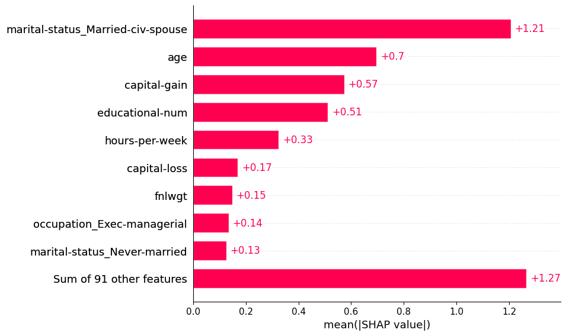

```python
shap.plots.bar(shap_vals)
```

```python
import plotly.io as pio
pio.renderers.default = "jupyterlab"
```